# The Languange of Rap Music

### Vocabulary Size

These graphs show a very interesting thing about language use. The Dataset Contained 149 Common Rappers and there seems to be a strong link between being a rapper with a very large Vocabulary and being a member of the Wu Tang Clan. On the other hand, the single solely christian Rapper in the Dataset, NF is the individual with the smallest value. NF, Strongly believes in not using Swear Words so it is interesting that most morale rappers may have the smallest Vocabulary.

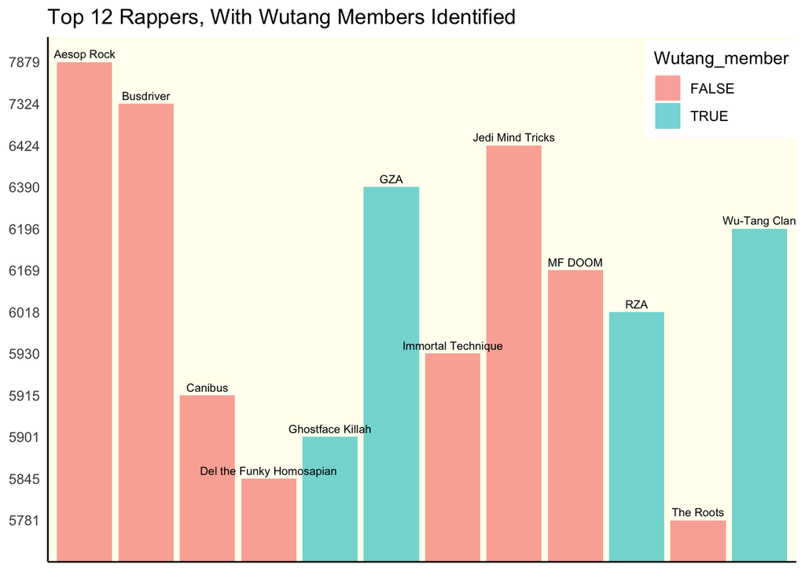

[figure not shown]

There also shows that there doesn’t seem to be much of a correlation between, Vocabulary size and Era, showing that as swearing increased and decreased, the Vocabulary size didn’t change. It’s also notable to show that almost all the rappers at the beginning are from the east coast and the rappers with the smallest vocabularies started to come out in the 2000’s suggesting that the language may be dumbed down in rap.

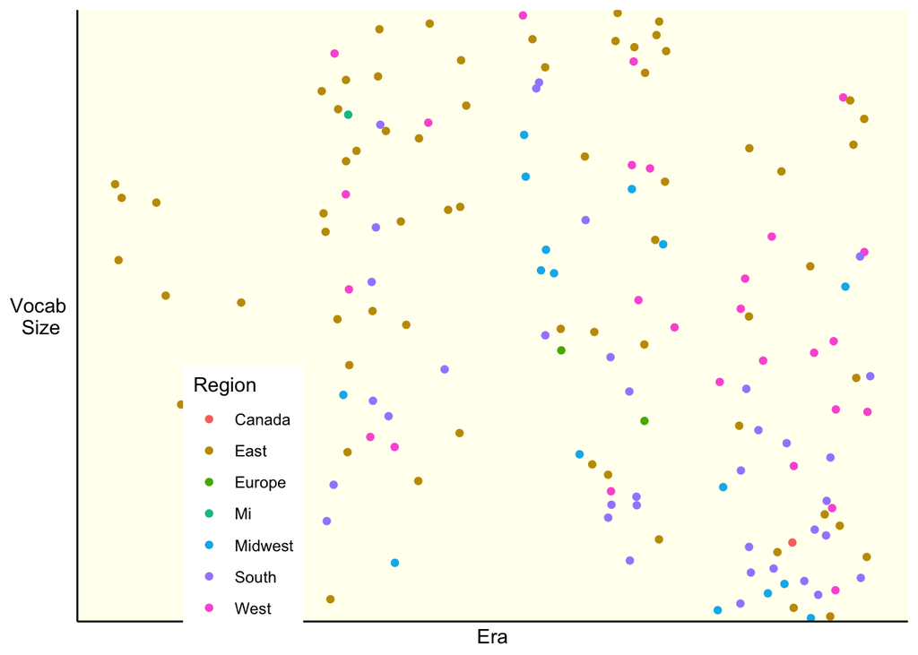

### Conclusions

Like many other things the language used in rap music can not be simplified in a single sentence. There is deep richness used in much rap music and sometimes the very people who use the most swear words are often the same people who used Shakespearean level vocabulary. There is still much profanity used in rap but the words used are not necessarily the ones with the most valence but there can definitely be more investigation into the conclusions of this paper.

I believe that the final grade I deserve for this piece of work should be excellent as I have used outside data from 2 different data sources. I think I communicated well to a subject area audience.

Data Sources: Sarah Bartlett and The Pudding